# Student Name: Godfred Asamoah

# Student ID: @03054184

# Project Title: World Happiness Index Analysis

## Introduction to the Dataset

The World Happiness Report is a landmark survey that ranks global happiness across countries. It assesses various factors contributing to well-being, including economic production, social support, and more. [Dataset Source on Kaggle](https://www.kaggle.com/datasets/unsdsn/world-happiness)

## Dataset Source

The dataset is sourced from Kaggle: [World Happiness Report](https://www.kaggle.com/datasets/unsdsn/world-happiness)

## Background Context

Understanding the factors that contribute to happiness can inform policy decisions and promote societal well-being. This dataset provides insights into the determinants of happiness across different nations, enabling comparative analyses and fostering a deeper understanding of global happiness trends.

## Data Wrangling and Descriptive Statistics

### Loading the Dataset

```python
import pandas as pd

# Load the dataset
file_path = '2015 (1).csv'
df = pd.read_csv(file_path)
df.head()
```

|  | Country | Region | Happiness Rank | Happiness Score | Standard Error | Economy (GDP per Capita) | Family | Health (Life Expectancy) | Freedom | Trust (Government Corruption) | Generosity | Dystopia Residual |
| --- | --- | --- | --- | --- | --- | --- | --- | --- | --- | --- | --- | --- |
| 0 | Switzerland | Western Europe | 1 | 7.587 | 0.03411 | 1.39651 | 1.34951 | 0.94143 | 0.66557 | 0.41978 | 0.29678 | 2.51738 |
| 1 | Iceland | Western Europe | 2 | 7.561 | 0.04884 | 1.30232 | 1.40223 | 0.94784 | 0.62877 | 0.14145 | 0.43630 | 2.70201 |
| 2 | Denmark | Western Europe | 3 | 7.527 | 0.03328 | 1.32548 | 1.36058 | 0.87464 | 0.64938 | 0.48357 | 0.34139 | 2.49204 |
| 3 | Norway | Western Europe | 4 | 7.522 | 0.03880 | 1.45900 | 1.33095 | 0.88521 | 0.66973 | 0.36503 | 0.34699 | 2.46531 |
| 4 | Canada | North America | 5 | 7.427 | 0.03553 | 1.32629 | 1.32261 | 0.90563 | 0.63297 | 0.32957 | 0.45811 | 2.45176 |

## Section I: Dataset Overview and Structure

```python
df.shape
```

```
(158, 12)
```

```python
df.info()
```

```
<class 'pandas.core.frame.DataFrame'>
RangeIndex: 158 entries, 0 to 157
Data columns (total 12 columns):
 #   Column                         Non-Null Count  Dtype
---  ------                         --------------  -----
 0   Country                        158 non-null    object
 1   Region                         158 non-null    object
 2   Happiness Rank                 158 non-null    int64
 3   Happiness Score                158 non-null    float64
 4   Standard Error                 158 non-null    float64
 5   Economy (GDP per Capita)       158 non-null    float64
 6   Family                         158 non-null    float64
 7   Health (Life Expectancy)       158 non-null    float64
 8   Freedom                        158 non-null    float64
 9   Trust (Government Corruption)  158 non-null    float64
 10  Generosity                     158 non-null    float64
 11  Dystopia Residual              158 non-null    float64
dtypes: float64(9), int64(1), object(2)
memory usage: 14.9+ KB
```

```python
df.head()
```

|  | Country | Region | Happiness Rank | Happiness Score | Standard Error | Economy (GDP per Capita) | Family | Health (Life Expectancy) | Freedom | Trust (Government Corruption) | Generosity | Dystopia Residual |
| --- | --- | --- | --- | --- | --- | --- | --- | --- | --- | --- | --- | --- |
| 0 | Switzerland | Western Europe | 1 | 7.587 | 0.03411 | 1.39651 | 1.34951 | 0.94143 | 0.66557 | 0.41978 | 0.29678 | 2.51738 |
| 1 | Iceland | Western Europe | 2 | 7.561 | 0.04884 | 1.30232 | 1.40223 | 0.94784 | 0.62877 | 0.14145 | 0.43630 | 2.70201 |
| 2 | Denmark | Western Europe | 3 | 7.527 | 0.03328 | 1.32548 | 1.36058 | 0.87464 | 0.64938 | 0.48357 | 0.34139 | 2.49204 |
| 3 | Norway | Western Europe | 4 | 7.522 | 0.03880 | 1.45900 | 1.33095 | 0.88521 | 0.66973 | 0.36503 | 0.34699 | 2.46531 |
| 4 | Canada | North America | 5 | 7.427 | 0.03553 | 1.32629 | 1.32261 | 0.90563 | 0.63297 | 0.32957 | 0.45811 | 2.45176 |

```python
df.tail()
```

|  | Country | Region | Happiness Rank | Happiness Score | Standard Error | Economy (GDP per Capita) | Family | Health (Life Expectancy) | Freedom | Trust (Government Corruption) | Generosity | Dystopia Residual |
| --- | --- | --- | --- | --- | --- | --- | --- | --- | --- | --- | --- | --- |
| 153 | Rwanda | Sub-Saharan Africa | 154 | 3.465 | 0.03464 | 0.22208 | 0.77370 | 0.42864 | 0.59201 | 0.55191 | 0.22628 | 0.67042 |
| 154 | Benin | Sub-Saharan Africa | 155 | 3.340 | 0.03656 | 0.28665 | 0.35386 | 0.31910 | 0.48450 | 0.08010 | 0.18260 | 1.63328 |
| 155 | Syria | Middle East and Northern Africa | 156 | 3.006 | 0.05015 | 0.66320 | 0.47489 | 0.72193 | 0.15684 | 0.18906 | 0.47179 | 0.32858 |
| 156 | Burundi | Sub-Saharan Africa | 157 | 2.905 | 0.08658 | 0.01530 | 0.41587 | 0.22396 | 0.11850 | 0.10062 | 0.19727 | 1.83302 |
| 157 | Togo | Sub-Saharan Africa | 158 | 2.839 | 0.06727 | 0.20868 | 0.13995 | 0.28443 | 0.36453 | 0.10731 | 0.16681 | 1.56726 |

The dataset contains both **categorical** (e.g., Country, Region) and **numerical** variables (e.g., GDP, Health). There are no datetime values.

```python
df.isnull().sum()
```

```
Country                          0
Region                           0
Happiness Rank                   0
Happiness Score                  0
Standard Error                   0
Economy (GDP per Capita)         0
Family                           0
Health (Life Expectancy)         0
Freedom                          0
Trust (Government Corruption)    0
Generosity                       0
Dystopia Residual                0
dtype: int64
```

Missing values will be handled by either imputing with the mean or removing rows with significant null values depending on their count and importance.

## Section II: Data Cleaning & Indexing

```python
df.duplicated().sum()
```

```
0
```

```python
df = df.drop_duplicates()
```

### Adding the 'Development Level' Column

To categorize countries based on their GDP per capita, we'll add a new categorical column named 'Development Level'.

```python
import numpy as np
import pandas as pd

# Define the percentiles for GDP per capita
percentiles = np.percentile(df['Economy (GDP per Capita)'], [25, 50, 75, 100])

def classify_GDP(gdp):
    if pd.isnull(gdp):
        return 'Unknown'
    elif gdp <= percentiles[0]:
        return 'Low'
    elif gdp <= percentiles[1]:
        return 'Low Middle'
    elif gdp <= percentiles[2]:
        return 'Middle'
    else:
        return 'High'

# Copy the DataFrame and add new categorical column
df_cleaned = df.copy()
df_cleaned['Development Level'] = df_cleaned['Economy (GDP per Capita)'].apply(classify_GDP)

# Show a preview of the updated DataFrame
print(df_cleaned[['Country', 'Economy (GDP per Capita)', 'Development Level']].head())

# Save the cleaned DataFrame to a CSV file
df_cleaned.to_csv('cleaned_data.csv', index=False)
```

```
       Country  Economy (GDP per Capita) Development Level
0  Switzerland                   1.39651              High
1      Iceland                   1.30232              High
2      Denmark                   1.32548              High
3       Norway                   1.45900              High
4       Canada                   1.32629              High
```

### Descriptive Statistics

```python
# Descriptive statistics for numerical columns
df_cleaned.describe()
```

|  | Happiness Rank | Happiness Score | Standard Error | Economy (GDP per Capita) | Family | Health (Life Expectancy) | Freedom | Trust (Government Corruption) | Generosity | Dystopia Residual |
| --- | --- | --- | --- | --- | --- | --- | --- | --- | --- | --- |
| count | 158.000000 | 158.000000 | 158.000000 | 158.000000 | 158.000000 | 158.000000 | 158.000000 | 158.000000 | 158.000000 | 158.000000 |
| mean | 79.493671 | 5.375734 | 0.047885 | 0.846137 | 0.991046 | 0.630259 | 0.428615 | 0.143422 | 0.237296 | 2.098977 |
| std | 45.754363 | 1.145010 | 0.017146 | 0.403121 | 0.272369 | 0.247078 | 0.150693 | 0.120034 | 0.126685 | 0.553550 |
| min | 1.000000 | 2.839000 | 0.018480 | 0.000000 | 0.000000 | 0.000000 | 0.000000 | 0.000000 | 0.000000 | 0.328580 |
| 25% | 40.250000 | 4.526000 | 0.037268 | 0.545808 | 0.856823 | 0.439185 | 0.328330 | 0.061675 | 0.150553 | 1.759410 |
| 50% | 79.500000 | 5.232500 | 0.043940 | 0.910245 | 1.029510 | 0.696705 | 0.435515 | 0.107220 | 0.216130 | 2.095415 |
| 75% | 118.750000 | 6.243750 | 0.052300 | 1.158448 | 1.214405 | 0.811013 | 0.549092 | 0.180255 | 0.309883 | 2.462415 |
| max | 158.000000 | 7.587000 | 0.136930 | 1.690420 | 1.402230 | 1.025250 | 0.669730 | 0.551910 | 0.795880 | 3.602140 |

```python
# Value counts for the new 'Development Level' column
df_cleaned['Development Level'].value_counts()
```

```
Development Level
High          40
Low           40
Middle        39
Low Middle    39
Name: count, dtype: int64
```

```python
# Filter example 1: Countries with GDP above 1.4
df_cleaned[df['Economy (GDP per Capita)'] > 1.4]
```

|  | Country | Region | Happiness Rank | Happiness Score | Standard Error | Economy (GDP per Capita) | Family | Health (Life Expectancy) | Freedom | Trust (Government Corruption) | Generosity | Dystopia Residual | Development Level |
| --- | --- | --- | --- | --- | --- | --- | --- | --- | --- | --- | --- | --- | --- |
| 3 | Norway | Western Europe | 4 | 7.522 | 0.03880 | 1.45900 | 1.33095 | 0.88521 | 0.66973 | 0.36503 | 0.34699 | 2.46531 | High |
| 16 | Luxembourg | Western Europe | 17 | 6.946 | 0.03499 | 1.56391 | 1.21963 | 0.91894 | 0.61583 | 0.37798 | 0.28034 | 1.96961 | High |
| 19 | United Arab Emirates | Middle East and Northern Africa | 20 | 6.901 | 0.03729 | 1.42727 | 1.12575 | 0.80925 | 0.64157 | 0.38583 | 0.26428 | 2.24743 | High |
| 23 | Singapore | Southeastern Asia | 24 | 6.798 | 0.03780 | 1.52186 | 1.02000 | 1.02525 | 0.54252 | 0.49210 | 0.31105 | 1.88501 | High |
| 27 | Qatar | Middle East and Northern Africa | 28 | 6.611 | 0.06257 | 1.69042 | 1.07860 | 0.79733 | 0.64040 | 0.52208 | 0.32573 | 1.55674 | High |
| 38 | Kuwait | Middle East and Northern Africa | 39 | 6.295 | 0.04456 | 1.55422 | 1.16594 | 0.72492 | 0.55499 | 0.25609 | 0.16228 | 1.87634 | High |

```python
# Filter example 2: Countries in the Western Europe region
df_cleaned[df['Region'] == 'Western Europe']
```

|  | Country | Region | Happiness Rank | Happiness Score | Standard Error | Economy (GDP per Capita) | Family | Health (Life Expectancy) | Freedom | Trust (Government Corruption) | Generosity | Dystopia Residual | Development Level |
| --- | --- | --- | --- | --- | --- | --- | --- | --- | --- | --- | --- | --- | --- |
| 0 | Switzerland | Western Europe | 1 | 7.587 | 0.03411 | 1.39651 | 1.34951 | 0.94143 | 0.66557 | 0.41978 | 0.29678 | 2.51738 | High |
| 1 | Iceland | Western Europe | 2 | 7.561 | 0.04884 | 1.30232 | 1.40223 | 0.94784 | 0.62877 | 0.14145 | 0.43630 | 2.70201 | High |
| 2 | Denmark | Western Europe | 3 | 7.527 | 0.03328 | 1.32548 | 1.36058 | 0.87464 | 0.64938 | 0.48357 | 0.34139 | 2.49204 | High |
| 3 | Norway | Western Europe | 4 | 7.522 | 0.03880 | 1.45900 | 1.33095 | 0.88521 | 0.66973 | 0.36503 | 0.34699 | 2.46531 | High |
| 5 | Finland | Western Europe | 6 | 7.406 | 0.03140 | 1.29025 | 1.31826 | 0.88911 | 0.64169 | 0.41372 | 0.23351 | 2.61955 | High |
| 6 | Netherlands | Western Europe | 7 | 7.378 | 0.02799 | 1.32944 | 1.28017 | 0.89284 | 0.61576 | 0.31814 | 0.47610 | 2.46570 | High |
| 7 | Sweden | Western Europe | 8 | 7.364 | 0.03157 | 1.33171 | 1.28907 | 0.91087 | 0.65980 | 0.43844 | 0.36262 | 2.37119 | High |
| 12 | Austria | Western Europe | 13 | 7.200 | 0.03751 | 1.33723 | 1.29704 | 0.89042 | 0.62433 | 0.18676 | 0.33088 | 2.53320 | High |
| 16 | Luxembourg | Western Europe | 17 | 6.946 | 0.03499 | 1.56391 | 1.21963 | 0.91894 | 0.61583 | 0.37798 | 0.28034 | 1.96961 | High |
| 17 | Ireland | Western Europe | 18 | 6.940 | 0.03676 | 1.33596 | 1.36948 | 0.89533 | 0.61777 | 0.28703 | 0.45901 | 1.97570 | High |
| 18 | Belgium | Western Europe | 19 | 6.937 | 0.03595 | 1.30782 | 1.28566 | 0.89667 | 0.58450 | 0.22540 | 0.22250 | 2.41484 | High |
| 20 | United Kingdom | Western Europe | 21 | 6.867 | 0.01866 | 1.26637 | 1.28548 | 0.90943 | 0.59625 | 0.32067 | 0.51912 | 1.96994 | High |
| 25 | Germany | Western Europe | 26 | 6.750 | 0.01848 | 1.32792 | 1.29937 | 0.89186 | 0.61477 | 0.21843 | 0.28214 | 2.11569 | High |
| 28 | France | Western Europe | 29 | 6.575 | 0.03512 | 1.27778 | 1.26038 | 0.94579 | 0.55011 | 0.20646 | 0.12332 | 2.21126 | High |
| 35 | Spain | Western Europe | 36 | 6.329 | 0.03468 | 1.23011 | 1.31379 | 0.95562 | 0.45951 | 0.06398 | 0.18227 | 2.12367 | High |
| 36 | Malta | Western Europe | 37 | 6.302 | 0.04206 | 1.20740 | 1.30203 | 0.88721 | 0.60365 | 0.13586 | 0.51752 | 1.64880 | High |
| 49 | Italy | Western Europe | 50 | 5.948 | 0.03914 | 1.25114 | 1.19777 | 0.95446 | 0.26236 | 0.02901 | 0.22823 | 2.02518 | High |
| 65 | North Cyprus | Western Europe | 66 | 5.695 | 0.05635 | 1.20806 | 1.07008 | 0.92356 | 0.49027 | 0.14280 | 0.26169 | 1.59888 | High |
| 66 | Cyprus | Western Europe | 67 | 5.689 | 0.05580 | 1.20813 | 0.89318 | 0.92356 | 0.40672 | 0.06146 | 0.30638 | 1.88931 | High |
| 87 | Portugal | Western Europe | 88 | 5.102 | 0.04802 | 1.15991 | 1.13935 | 0.87519 | 0.51469 | 0.01078 | 0.13719 | 1.26462 | High |
| 101 | Greece | Western Europe | 102 | 4.857 | 0.05062 | 1.15406 | 0.92933 | 0.88213 | 0.07699 | 0.01397 | 0.00000 | 1.80101 | Middle |

```python
df_cleaned['Region'].value_counts()
```

```
Region
Sub-Saharan Africa                 40
Central and Eastern Europe         29
Latin America and Caribbean        22
Western Europe                     21
Middle East and Northern Africa    20
Southeastern Asia                   9
Southern Asia                       7
Eastern Asia                        6
North America                       2
Australia and New Zealand           2
Name: count, dtype: int64
```

```python
# Group by Region and compute average Happiness Score
df_cleaned.groupby('Region')['Happiness Score'].mean().sort_values(ascending=False)
```

```
Region
Australia and New Zealand          7.285000
North America                      7.273000
Western Europe                     6.689619
Latin America and Caribbean        6.144682
Eastern Asia                       5.626167
Middle East and Northern Africa    5.406900
Central and Eastern Europe         5.332931
Southeastern Asia                  5.317444
Southern Asia                      4.580857
Sub-Saharan Africa                 4.202800
Name: Happiness Score, dtype: float64
```

```python
# Group by development level and compute average Happiness Score
df_cleaned.groupby('Development Level')['Happiness Score'].mean().sort_values(ascending=False)
```

```
Development Level
High          6.652675
Middle        5.623256
Low Middle    5.047308
Low           4.177675
Name: Happiness Score, dtype: float64
```

```python
df_cleaned['Development Level'].value_counts()
```

```
Development Level
High          40
Low           40
Middle        39
Low Middle    39
Name: count, dtype: int64
```

## Section IV: Observations & Next Steps

- Countries in Western Europe generally have higher happiness scores.
- GDP per capita plays a significant role in development level and perceived well-being.

**Further questions for Part 2:**

1. Is there a visible correlation between GDP and Happiness Score?
2. How do regions compare in terms of health and freedom indicators using visuals?

## Final Summary

This notebook provides a structured approach to examining the 2015 World Happiness dataset. We performed initial data cleaning, classified countries by GDP, and calculated descriptive statistics. Our analysis found significant trends in GDP, health, and geographic region, which will guide the visual exploration in Part 2.

# SECTION I: Individual, Comparative, and Grouped Visualizations

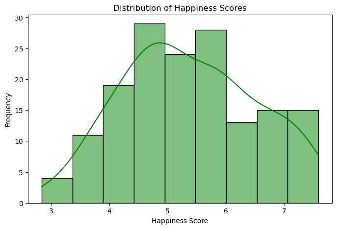

```python
# Histogram of Happiness Score
import matplotlib.pyplot as plt
import seaborn as sns
plt.figure(figsize=(8, 5))
sns.histplot(df['Happiness Score'], kde=True, color='green')
plt.title('Distribution of Happiness Scores')
plt.xlabel('Happiness Score')
plt.ylabel('Frequency')
plt.show()
```

The histogram shows that most countries have happiness scores between 4 and 7, suggesting a moderate level of happiness globally. Very high or very low happiness scores are rare.

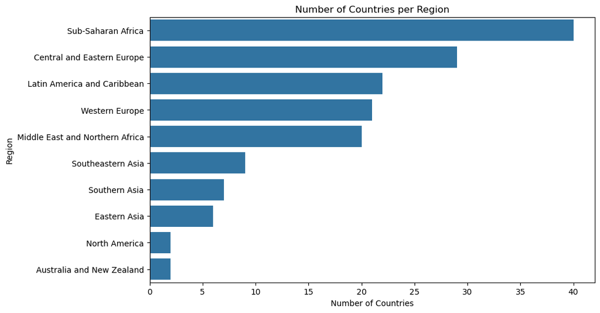

```python
# Count plot of countries by Region
import matplotlib.pyplot as plt
import seaborn as sns
plt.figure(figsize=(10, 6))
sns.countplot(y='Region', data=df, order=df['Region'].value_counts().index)
plt.title('Number of Countries per Region')
plt.xlabel('Number of Countries')
plt.ylabel('Region')
plt.show()
```

This count plot reveals that Sub-Saharan Africa has the highest number of countries in the dataset, followed by Central and Eastern Europe. Regions like North America and Australia & New Zealand have fewer represented countries.

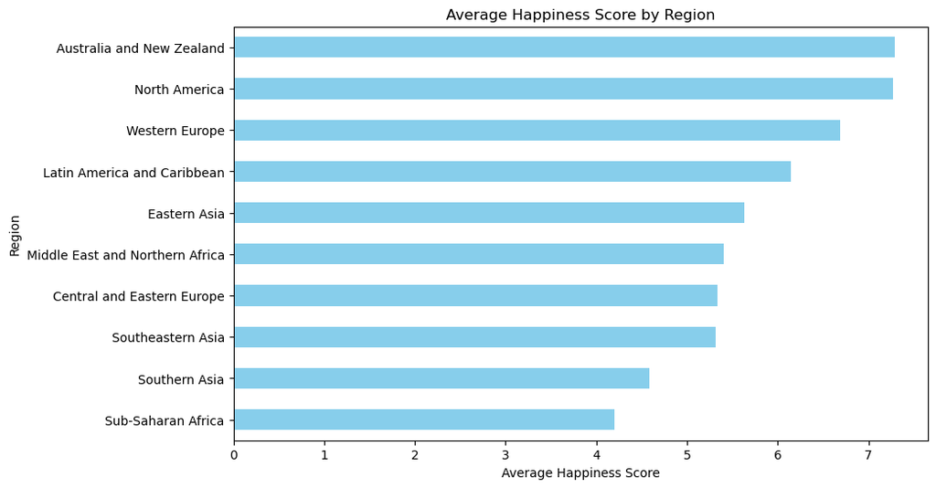

```python
# Average Happiness Score by Region
region_avg = df.groupby('Region')['Happiness Score'].mean().sort_values()
import matplotlib.pyplot as plt
import seaborn as sns
plt.figure(figsize=(10, 6))
region_avg.plot(kind='barh', color='skyblue')
plt.title('Average Happiness Score by Region')
plt.xlabel('Average Happiness Score')
plt.ylabel('Region')
plt.show()
```

Regions like Western Europe, North America, and Australia & New Zealand rank highest in happiness, while Sub-Saharan Africa and Southern Asia rank lower. Economic conditions, health, and freedom may explain these differences.

# SECTION II: Relationship Visualizations

## Scatter Plot: GDP vs Happiness Score

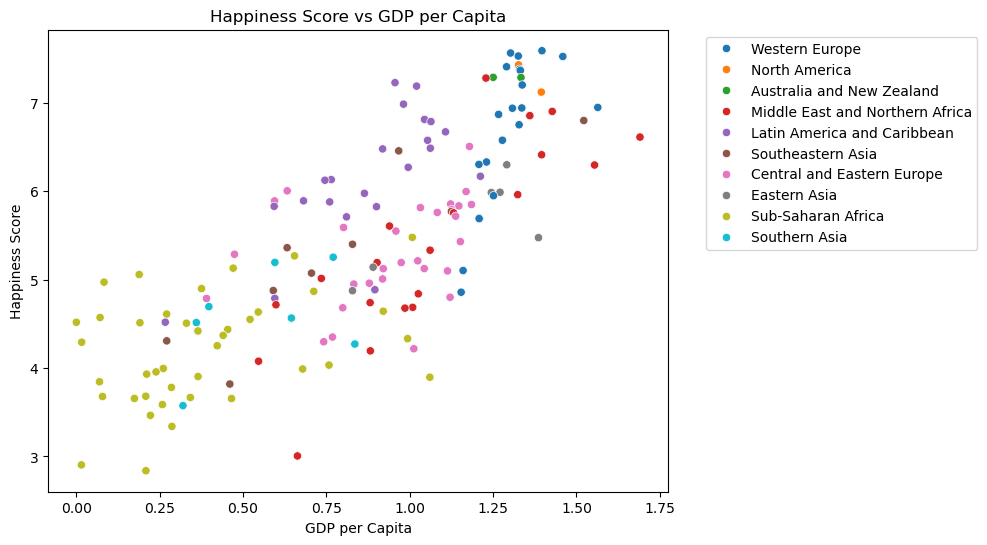

```python
import matplotlib.pyplot as plt
import seaborn as sns
plt.figure(figsize=(8, 6))
sns.scatterplot(data=df, x='Economy (GDP per Capita)', y='Happiness Score', hue='Region')
plt.title('Happiness Score vs GDP per Capita')
plt.xlabel('GDP per Capita')
plt.ylabel('Happiness Score')
plt.legend(bbox_to_anchor=(1.05, 1), loc='upper left')
plt.show()
```

A positive trend is visible — countries with higher GDP per capita tend to have higher happiness scores. There are a few outliers, but wealthier nations generally report greater happiness.

## Heatmap of Correlations

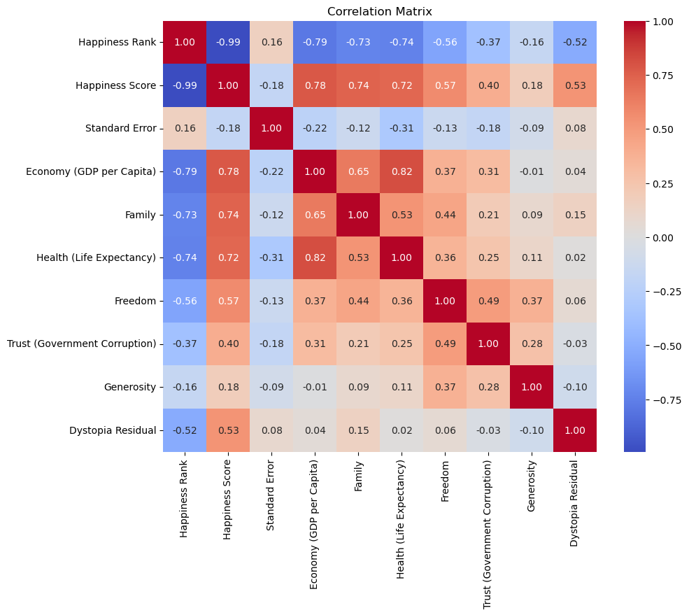

```python
import matplotlib.pyplot as plt
import seaborn as sns
plt.figure(figsize=(10, 8))
corr = df.corr(numeric_only=True)
sns.heatmap(corr, annot=True, cmap='coolwarm', fmt='.2f')
plt.title('Correlation Matrix')
plt.show()
```

The heatmap shows strong correlations between happiness score and GDP, family, and health (life expectancy). Trust in government and freedom also show moderate positive correlations.

## Boxplot of GDP by Region

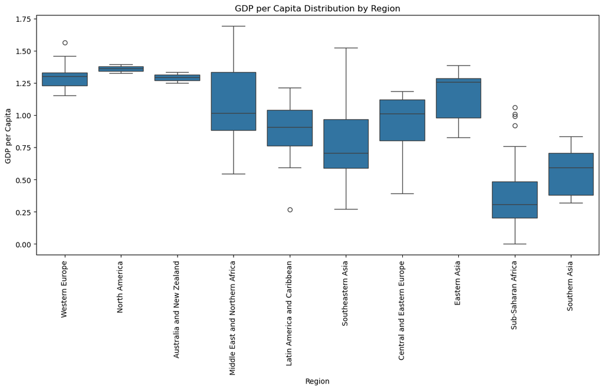

```python
import matplotlib.pyplot as plt
import seaborn as sns

plt.figure(figsize=(14, 6))
sns.boxplot(data=df, x='Region', y='Economy (GDP per Capita)')
plt.xticks(rotation=90)
plt.title('GDP per Capita Distribution by Region')
plt.xlabel('Region')
plt.ylabel('GDP per Capita')
plt.show()
```

## Pair Plot of Key Happiness Indicators

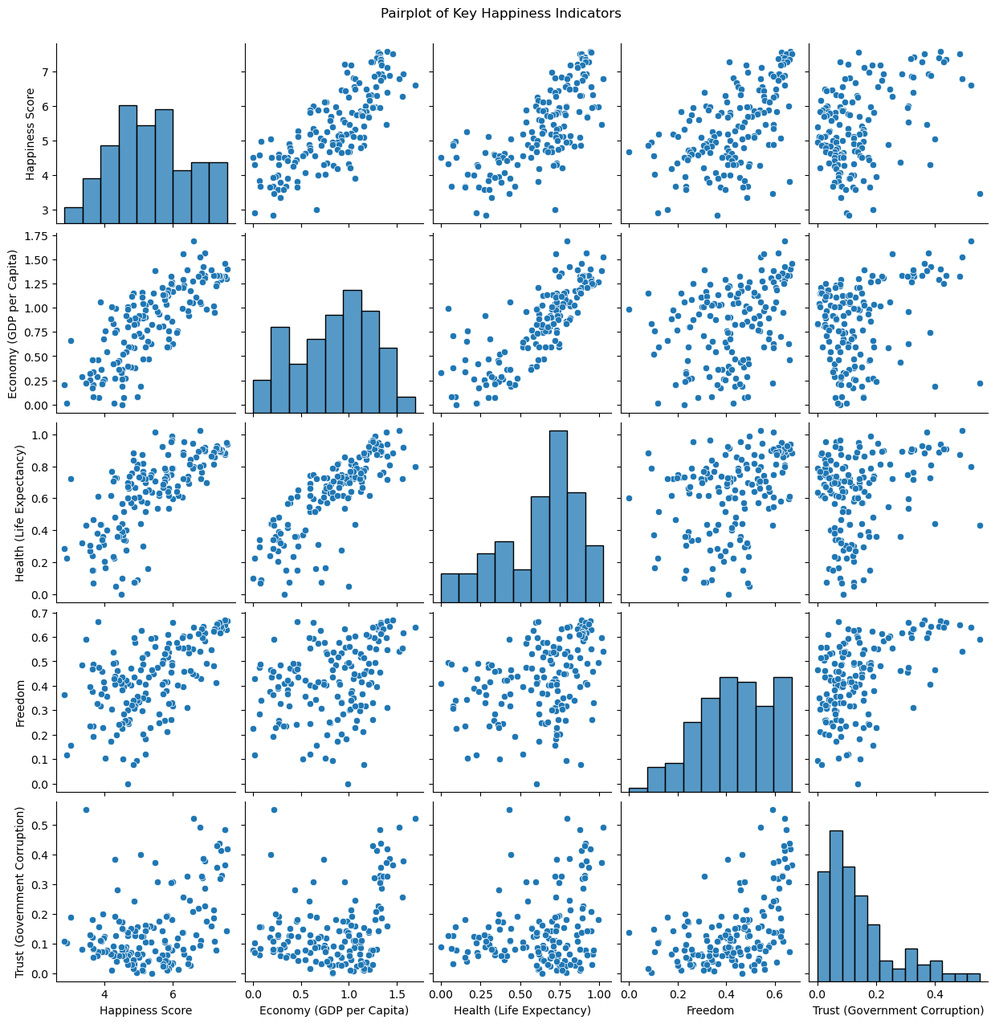

```python
import matplotlib.pyplot as plt
import seaborn as sns

selected_cols = ['Happiness Score', 'Economy (GDP per Capita)', 'Health (Life Expectancy)', 'Freedom', 'Trust (Government Corruption)']
sns.pairplot(df[selected_cols])
plt.suptitle('Pairplot of Key Happiness Indicators', y=1.02)
plt.show()
```

## Bar Plot: Top vs Bottom 10 Comparison

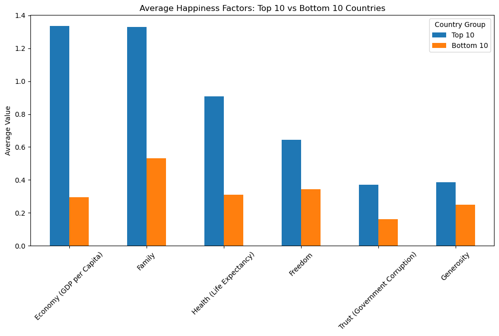

```python
import matplotlib.pyplot as plt
import seaborn as sns

top10 = df.sort_values(by='Happiness Score', ascending=False).head(10)
bottom10 = df.sort_values(by='Happiness Score', ascending=True).head(10)

top_mean = top10[['Economy (GDP per Capita)', 'Family', 'Health (Life Expectancy)', 'Freedom', 'Trust (Government Corruption)', 'Generosity']].mean()
bottom_mean = bottom10[['Economy (GDP per Capita)', 'Family', 'Health (Life Expectancy)', 'Freedom', 'Trust (Government Corruption)', 'Generosity']].mean()

compare_df = pd.DataFrame({'Top 10': top_mean, 'Bottom 10': bottom_mean})

compare_df.plot(kind='bar', figsize=(12, 6))
plt.title('Average Happiness Factors: Top 10 vs Bottom 10 Countries')
plt.ylabel('Average Value')
plt.xticks(rotation=45)
plt.legend(title='Country Group')
plt.show()
```

## 📊 Visualization Insights & Interpretation

### 4. **GDP vs. Happiness Score**

The scatter plot shows a **positive correlation** between GDP per capita and happiness score. However, it's not a perfect relationship — some countries with moderate GDPs also report high happiness, suggesting other factors like **health, freedom, and social support** play vital roles.

### 5. **Correlation Heatmap**

Strong positive correlations were found between **Happiness Score** and **GDP per Capita**, **Family**, and **Health (Life Expectancy)**. Interestingly, **trust in government** shows a weaker correlation, suggesting that perceptions of corruption may not strongly influence happiness in some countries.

### 6. **GDP Distribution by Region (Boxplot)**

The boxplot reveals **extreme disparities** in GDP per capita across regions. **Western Europe** and **North America** exhibit high medians and less variability, while **Sub-Saharan Africa** shows lower medians and wider spreads, indicating **economic inequality**.

## ✅ Takeaways from the Data

After exploring the 2015 World Happiness dataset through a variety of visualizations, several important insights emerge:

1. **Wealth and Well-being Go Hand in Hand**  
   There is a strong relationship between GDP per capita and happiness. Countries with higher income levels tend to score higher in happiness, though it is not the only factor.
2. **Health and Social Support Matter Deeply**  
   Health (life expectancy) and family (social support) are both highly correlated with happiness. These aspects appear as consistent pillars of well-being across the top-ranked countries.
3. **Geographic and Regional Disparities Exist**  
   Western Europe and North America consistently rank higher in happiness scores, while Sub-Saharan Africa and Southern Asia are at the lower end. This reflects disparities in access to economic resources, healthcare, education, and governance.
4. **Trust and Freedom Have a Role — But It’s Complex**  
   While freedom shows a moderate correlation with happiness, trust in government has a weaker correlation. This suggests that while political transparency may enhance well-being, it’s not the strongest driver.
5. **Generosity Isn’t Just About Money**  
   Countries with high generosity scores aren't always the wealthiest. This implies that generosity can be driven by cultural values and may contribute to happiness in less economically affluent nations.
6. **Happiness is Multi-Faceted**  
   No single variable explains happiness completely. The happiest countries tend to have balanced high scores across multiple dimensions: economic security, health, social support, freedom, and to some extent, trust and generosity.
7. **Outliers Are Insightful**  
   Some countries defy expectations — for instance, nations with average GDP but relatively high happiness, suggesting strong community, culture, or other well-being factors not captured by traditional metrics.

### 🎯 Final Thought

This project highlights the power of **data visualization in storytelling**. By turning raw data into intuitive graphs, we not only detect trends and relationships, but also generate meaningful conversations about the human experience. It reminds us that behind every data point is a society striving for a better quality of life.